# Risk Factor Analysis

## Outcome Variable

**Outcome Variable:** wast_rec90d

## Predictor Variables

**Intervention Variable:** mbmi

**Adjustment Set:**

- arm
- W_mage
- meducyrs
- feducyrs
- single
- brthmon
- delta_W_mage
- delta_meducyrs
- delta_feducyrs
- delta_single
- delta_brthmon

## Stratifying Variables

The analysis was stratified on these variable(s):

- agecat
- studyid
- country

## Data Summary

| agecat | studyid | country | mbmi | wast_rec90d | n_cell | n |
| --- | --- | --- | --- | --- | --- | --- |
| 0-24 months | ki0047075b-MAL-ED | BANGLADESH | Normal weight | 0 | 30 | 122 |
| 0-24 months | ki0047075b-MAL-ED | BANGLADESH | Normal weight | 1 | 63 | 122 |
| 0-24 months | ki0047075b-MAL-ED | BANGLADESH | Underweight | 0 | 14 | 122 |
| 0-24 months | ki0047075b-MAL-ED | BANGLADESH | Underweight | 1 | 15 | 122 |
| 0-24 months | ki0047075b-MAL-ED | BRAZIL | Normal weight | 0 | 6 | 23 |
| 0-24 months | ki0047075b-MAL-ED | BRAZIL | Normal weight | 1 | 15 | 23 |
| 0-24 months | ki0047075b-MAL-ED | BRAZIL | Underweight | 0 | 0 | 23 |
| 0-24 months | ki0047075b-MAL-ED | BRAZIL | Underweight | 1 | 2 | 23 |
| 0-24 months | ki0047075b-MAL-ED | INDIA | Normal weight | 0 | 48 | 175 |
| 0-24 months | ki0047075b-MAL-ED | INDIA | Normal weight | 1 | 80 | 175 |
| 0-24 months | ki0047075b-MAL-ED | INDIA | Underweight | 0 | 22 | 175 |
| 0-24 months | ki0047075b-MAL-ED | INDIA | Underweight | 1 | 25 | 175 |
| 0-24 months | ki0047075b-MAL-ED | NEPAL | Normal weight | 0 | 20 | 93 |
| 0-24 months | ki0047075b-MAL-ED | NEPAL | Normal weight | 1 | 73 | 93 |
| 0-24 months | ki0047075b-MAL-ED | NEPAL | Underweight | 0 | 0 | 93 |
| 0-24 months | ki0047075b-MAL-ED | NEPAL | Underweight | 1 | 0 | 93 |
| 0-24 months | ki0047075b-MAL-ED | PERU | Normal weight | 0 | 5 | 34 |
| 0-24 months | ki0047075b-MAL-ED | PERU | Normal weight | 1 | 25 | 34 |
| 0-24 months | ki0047075b-MAL-ED | PERU | Underweight | 0 | 1 | 34 |
| 0-24 months | ki0047075b-MAL-ED | PERU | Underweight | 1 | 3 | 34 |
| 0-24 months | ki0047075b-MAL-ED | SOUTH AFRICA | Normal weight | 0 | 13 | 77 |
| 0-24 months | ki0047075b-MAL-ED | SOUTH AFRICA | Normal weight | 1 | 64 | 77 |
| 0-24 months | ki0047075b-MAL-ED | SOUTH AFRICA | Underweight | 0 | 0 | 77 |
| 0-24 months | ki0047075b-MAL-ED | SOUTH AFRICA | Underweight | 1 | 0 | 77 |
| 0-24 months | ki0047075b-MAL-ED | TANZANIA, UNITED REPUBLIC OF | Normal weight | 0 | 7 | 45 |
| 0-24 months | ki0047075b-MAL-ED | TANZANIA, UNITED REPUBLIC OF | Normal weight | 1 | 34 | 45 |
| 0-24 months | ki0047075b-MAL-ED | TANZANIA, UNITED REPUBLIC OF | Underweight | 0 | 1 | 45 |
| 0-24 months | ki0047075b-MAL-ED | TANZANIA, UNITED REPUBLIC OF | Underweight | 1 | 3 | 45 |
| 0-24 months | ki1000304b-SAS-CompFeed | INDIA | Normal weight | 0 | 287 | 744 |
| 0-24 months | ki1000304b-SAS-CompFeed | INDIA | Normal weight | 1 | 194 | 744 |

[output cut: 158 more lines]

The following strata were considered:

- agecat: 0-24 months, studyid: ki0047075b-MAL-ED, country: BANGLADESH
- agecat: 0-24 months, studyid: ki0047075b-MAL-ED, country: BRAZIL
- agecat: 0-24 months, studyid: ki0047075b-MAL-ED, country: INDIA
- agecat: 0-24 months, studyid: ki0047075b-MAL-ED, country: NEPAL
- agecat: 0-24 months, studyid: ki0047075b-MAL-ED, country: PERU
- agecat: 0-24 months, studyid: ki0047075b-MAL-ED, country: SOUTH AFRICA
- agecat: 0-24 months, studyid: ki0047075b-MAL-ED, country: TANZANIA, UNITED REPUBLIC OF
- agecat: 0-24 months, studyid: ki1000304b-SAS-CompFeed, country: INDIA
- agecat: 0-24 months, studyid: ki1017093-NIH-Birth, country: BANGLADESH
- agecat: 0-24 months, studyid: ki1017093b-PROVIDE, country: BANGLADESH
- agecat: 0-24 months, studyid: ki1017093c-NIH-Crypto, country: BANGLADESH
- agecat: 0-24 months, studyid: ki1066203-TanzaniaChild2, country: TANZANIA, UNITED REPUBLIC OF
- agecat: 0-24 months, studyid: ki1112895-iLiNS-Zinc, country: BURKINA FASO
- agecat: 0-24 months, studyid: ki1119695-PROBIT, country: BELARUS
- agecat: 0-24 months, studyid: ki1126311-ZVITAMBO, country: ZIMBABWE
- agecat: 0-24 months, studyid: ki1148112-LCNI-5, country: MALAWI
- agecat: 0-6 months, studyid: ki0047075b-MAL-ED, country: BANGLADESH
- agecat: 0-6 months, studyid: ki0047075b-MAL-ED, country: BRAZIL
- agecat: 0-6 months, studyid: ki0047075b-MAL-ED, country: INDIA
- agecat: 0-6 months, studyid: ki0047075b-MAL-ED, country: NEPAL
- agecat: 0-6 months, studyid: ki0047075b-MAL-ED, country: PERU
- agecat: 0-6 months, studyid: ki0047075b-MAL-ED, country: SOUTH AFRICA
- agecat: 0-6 months, studyid: ki0047075b-MAL-ED, country: TANZANIA, UNITED REPUBLIC OF
- agecat: 0-6 months, studyid: ki1000304b-SAS-CompFeed, country: INDIA
- agecat: 0-6 months, studyid: ki1017093-NIH-Birth, country: BANGLADESH
- agecat: 0-6 months, studyid: ki1017093b-PROVIDE, country: BANGLADESH
- agecat: 0-6 months, studyid: ki1017093c-NIH-Crypto, country: BANGLADESH
- agecat: 0-6 months, studyid: ki1066203-TanzaniaChild2, country: TANZANIA, UNITED REPUBLIC OF
- agecat: 0-6 months, studyid: ki1119695-PROBIT, country: BELARUS
- agecat: 0-6 months, studyid: ki1126311-ZVITAMBO, country: ZIMBABWE
- agecat: 0-6 months, studyid: ki1148112-LCNI-5, country: MALAWI
- agecat: 6-24 months, studyid: ki0047075b-MAL-ED, country: BANGLADESH
- agecat: 6-24 months, studyid: ki0047075b-MAL-ED, country: BRAZIL
- agecat: 6-24 months, studyid: ki0047075b-MAL-ED, country: INDIA
- agecat: 6-24 months, studyid: ki0047075b-MAL-ED, country: NEPAL
- agecat: 6-24 months, studyid: ki0047075b-MAL-ED, country: PERU
- agecat: 6-24 months, studyid: ki0047075b-MAL-ED, country: SOUTH AFRICA
- agecat: 6-24 months, studyid: ki0047075b-MAL-ED, country: TANZANIA, UNITED REPUBLIC OF
- agecat: 6-24 months, studyid: ki1000304b-SAS-CompFeed, country: INDIA
- agecat: 6-24 months, studyid: ki1017093-NIH-Birth, country: BANGLADESH
- agecat: 6-24 months, studyid: ki1017093b-PROVIDE, country: BANGLADESH
- agecat: 6-24 months, studyid: ki1017093c-NIH-Crypto, country: BANGLADESH
- agecat: 6-24 months, studyid: ki1066203-TanzaniaChild2, country: TANZANIA, UNITED REPUBLIC OF
- agecat: 6-24 months, studyid: ki1112895-iLiNS-Zinc, country: BURKINA FASO
- agecat: 6-24 months, studyid: ki1119695-PROBIT, country: BELARUS
- agecat: 6-24 months, studyid: ki1126311-ZVITAMBO, country: ZIMBABWE
- agecat: 6-24 months, studyid: ki1148112-LCNI-5, country: MALAWI

### Dropped Strata

Some strata were dropped due to rare outcomes:

- agecat: 0-24 months, studyid: ki0047075b-MAL-ED, country: BRAZIL
- agecat: 0-24 months, studyid: ki0047075b-MAL-ED, country: NEPAL
- agecat: 0-24 months, studyid: ki0047075b-MAL-ED, country: PERU
- agecat: 0-24 months, studyid: ki0047075b-MAL-ED, country: SOUTH AFRICA
- agecat: 0-24 months, studyid: ki0047075b-MAL-ED, country: TANZANIA, UNITED REPUBLIC OF
- agecat: 0-6 months, studyid: ki0047075b-MAL-ED, country: BRAZIL
- agecat: 0-6 months, studyid: ki0047075b-MAL-ED, country: NEPAL
- agecat: 0-6 months, studyid: ki0047075b-MAL-ED, country: PERU
- agecat: 0-6 months, studyid: ki0047075b-MAL-ED, country: SOUTH AFRICA
- agecat: 0-6 months, studyid: ki0047075b-MAL-ED, country: TANZANIA, UNITED REPUBLIC OF
- agecat: 0-6 months, studyid: ki1017093c-NIH-Crypto, country: BANGLADESH
- agecat: 0-6 months, studyid: ki1066203-TanzaniaChild2, country: TANZANIA, UNITED REPUBLIC OF
- agecat: 0-6 months, studyid: ki1148112-LCNI-5, country: MALAWI
- agecat: 6-24 months, studyid: ki0047075b-MAL-ED, country: BRAZIL
- agecat: 6-24 months, studyid: ki0047075b-MAL-ED, country: NEPAL
- agecat: 6-24 months, studyid: ki0047075b-MAL-ED, country: PERU
- agecat: 6-24 months, studyid: ki0047075b-MAL-ED, country: SOUTH AFRICA
- agecat: 6-24 months, studyid: ki0047075b-MAL-ED, country: TANZANIA, UNITED REPUBLIC OF
- agecat: 6-24 months, studyid: ki1017093c-NIH-Crypto, country: BANGLADESH
- agecat: 6-24 months, studyid: ki1066203-TanzaniaChild2, country: TANZANIA, UNITED REPUBLIC OF
- agecat: 6-24 months, studyid: ki1119695-PROBIT, country: BELARUS

## Methods Detail

We’re interested in the causal parameters $E[Y_a]$ for all values of $a \in \mathcal{A}$. These parameters represent the mean outcome if, possibly contrary to fact, we intervened to set all units to have $A=a$. Under the randomization and positivity assumptions, these are identified by the statistical parameters $\psi_a=E_W[E_{Y|A,W}(Y|A=a,W)]$. In addition, we’re interested in the mean of $Y$, $E[Y]$ under no intervention (the observed mean). We will estimate these parameters by using SuperLearner to fit the relevant likelihood factors – $E_{Y|A,W}(Y|A=a,W)$ and $p(A=a|W)$, and then updating our likelihood fit using a joint TMLE.

For unadjusted analyses ($W=\{\}$), initial likelihoods were estimated using Lrnr_glm to estimate the simple $E(Y|A)$ and Lrnr_mean to estimate $p(A)$. For adjusted analyses, a small library containing Lrnr_glmnet, Lrnr_xgboost, and Lrnr_mean was used.

Having estimated these parameters, we will then use the delta method to estimate relative risks and attributable risks relative to a prespecified baseline level of $A$.

# Results Detail

## Results Plots

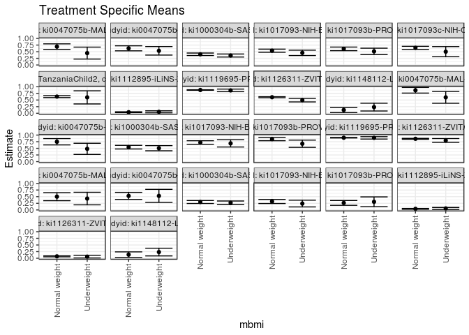

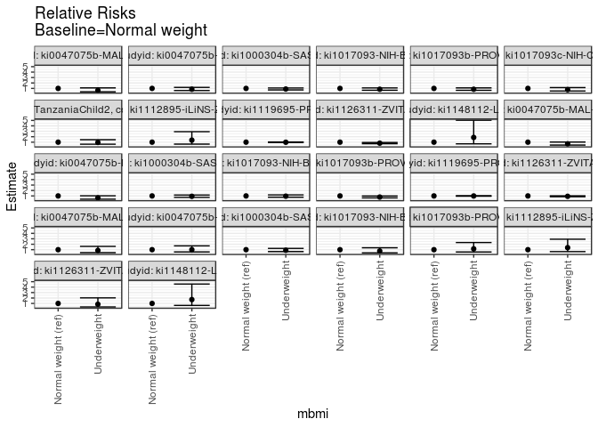

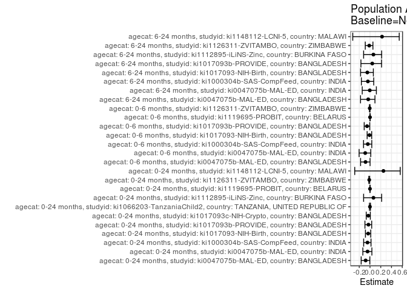

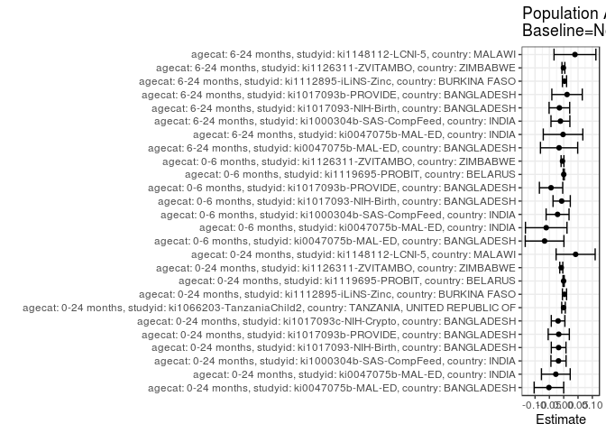

## Results Table

### Parameter: TSM

| agecat | studyid | country | intervention_level | baseline_level | estimate | ci_lower | ci_upper |
| --- | --- | --- | --- | --- | --- | --- | --- |
| 0-24 months | ki0047075b-MAL-ED | BANGLADESH | Normal weight | NA | 0.6909101 | 0.5866979 | 0.7951222 |
| 0-24 months | ki0047075b-MAL-ED | BANGLADESH | Underweight | NA | 0.4476333 | 0.2224524 | 0.6728143 |
| 0-24 months | ki0047075b-MAL-ED | INDIA | Normal weight | NA | 0.6274786 | 0.5333577 | 0.7215994 |
| 0-24 months | ki0047075b-MAL-ED | INDIA | Underweight | NA | 0.5339907 | 0.3735160 | 0.6944655 |
| 0-24 months | ki1000304b-SAS-CompFeed | INDIA | Normal weight | NA | 0.4025398 | 0.3553314 | 0.4497483 |
| 0-24 months | ki1000304b-SAS-CompFeed | INDIA | Underweight | NA | 0.3563702 | 0.2992083 | 0.4135321 |
| 0-24 months | ki1017093-NIH-Birth | BANGLADESH | Normal weight | NA | 0.5378685 | 0.4792409 | 0.5964961 |
| 0-24 months | ki1017093-NIH-Birth | BANGLADESH | Underweight | NA | 0.4568650 | 0.3558571 | 0.5578729 |
| 0-24 months | ki1017093b-PROVIDE | BANGLADESH | Normal weight | NA | 0.6066702 | 0.5389399 | 0.6744004 |
| 0-24 months | ki1017093b-PROVIDE | BANGLADESH | Underweight | NA | 0.5133422 | 0.3936355 | 0.6330490 |
| 0-24 months | ki1017093c-NIH-Crypto | BANGLADESH | Normal weight | NA | 0.6453462 | 0.5877499 | 0.7029426 |
| 0-24 months | ki1017093c-NIH-Crypto | BANGLADESH | Underweight | NA | 0.5010377 | 0.3100698 | 0.6920056 |
| 0-24 months | ki1066203-TanzaniaChild2 | TANZANIA, UNITED REPUBLIC OF | Normal weight | NA | 0.6288210 | 0.5904220 | 0.6672199 |
| 0-24 months | ki1066203-TanzaniaChild2 | TANZANIA, UNITED REPUBLIC OF | Underweight | NA | 0.6000000 | 0.3523180 | 0.8476820 |
| 0-24 months | ki1112895-iLiNS-Zinc | BURKINA FASO | Normal weight | NA | 0.0407524 | 0.0253994 | 0.0561053 |
| 0-24 months | ki1112895-iLiNS-Zinc | BURKINA FASO | Underweight | NA | 0.0559441 | 0.0192211 | 0.0926670 |
| 0-24 months | ki1119695-PROBIT | BELARUS | Normal weight | NA | 0.8772128 | 0.8668182 | 0.8876074 |
| 0-24 months | ki1119695-PROBIT | BELARUS | Underweight | NA | 0.8631630 | 0.8140639 | 0.9122622 |
| 0-24 months | ki1126311-ZVITAMBO | ZIMBABWE | Normal weight | NA | 0.6051882 | 0.5857897 | 0.6245867 |
| 0-24 months | ki1126311-ZVITAMBO | ZIMBABWE | Underweight | NA | 0.4950216 | 0.4288446 | 0.5611986 |
| 0-24 months | ki1148112-LCNI-5 | MALAWI | Normal weight | NA | 0.1250000 | 0.0290888 | 0.2209112 |
| 0-24 months | ki1148112-LCNI-5 | MALAWI | Underweight | NA | 0.2333333 | 0.0868920 | 0.3797747 |
| 0-6 months | ki0047075b-MAL-ED | BANGLADESH | Normal weight | NA | 0.8666667 | 0.7613735 | 0.9719599 |
| 0-6 months | ki0047075b-MAL-ED | BANGLADESH | Underweight | NA | 0.6000000 | 0.3771424 | 0.8228576 |
| 0-6 months | ki0047075b-MAL-ED | INDIA | Normal weight | NA | 0.7484999 | 0.6296551 | 0.8673447 |
| 0-6 months | ki0047075b-MAL-ED | INDIA | Underweight | NA | 0.4812678 | 0.2708755 | 0.6916601 |
| 0-6 months | ki1000304b-SAS-CompFeed | INDIA | Normal weight | NA | 0.5442614 | 0.4756176 | 0.6129053 |
| 0-6 months | ki1000304b-SAS-CompFeed | INDIA | Underweight | NA | 0.5050944 | 0.4073117 | 0.6028771 |
| 0-6 months | ki1017093-NIH-Birth | BANGLADESH | Normal weight | NA | 0.7201023 | 0.6535600 | 0.7866446 |
| 0-6 months | ki1017093-NIH-Birth | BANGLADESH | Underweight | NA | 0.6873501 | 0.5497679 | 0.8249322 |
| 0-6 months | ki1017093b-PROVIDE | BANGLADESH | Normal weight | NA | 0.8485944 | 0.7876309 | 0.9095578 |
| 0-6 months | ki1017093b-PROVIDE | BANGLADESH | Underweight | NA | 0.6737798 | 0.5381925 | 0.8093671 |
| 0-6 months | ki1119695-PROBIT | BELARUS | Normal weight | NA | 0.8999094 | 0.8900512 | 0.9097675 |
| 0-6 months | ki1119695-PROBIT | BELARUS | Underweight | NA | 0.8944468 | 0.8496806 | 0.9392131 |
| 0-6 months | ki1126311-ZVITAMBO | ZIMBABWE | Normal weight | NA | 0.8588158 | 0.8421687 | 0.8754629 |
| 0-6 months | ki1126311-ZVITAMBO | ZIMBABWE | Underweight | NA | 0.7973623 | 0.7255569 | 0.8691677 |
| 6-24 months | ki0047075b-MAL-ED | BANGLADESH | Normal weight | NA | 0.5000000 | 0.3485042 | 0.6514958 |
| 6-24 months | ki0047075b-MAL-ED | BANGLADESH | Underweight | NA | 0.4285714 | 0.1923941 | 0.6647488 |
| 6-24 months | ki0047075b-MAL-ED | INDIA | Normal weight | NA | 0.5285512 | 0.3953559 | 0.6617465 |
| 6-24 months | ki0047075b-MAL-ED | INDIA | Underweight | NA | 0.5294528 | 0.2830890 | 0.7758167 |
| 6-24 months | ki1000304b-SAS-CompFeed | INDIA | Normal weight | NA | 0.2990454 | 0.2431151 | 0.3549757 |
| 6-24 months | ki1000304b-SAS-CompFeed | INDIA | Underweight | NA | 0.2682708 | 0.1998999 | 0.3366418 |
| 6-24 months | ki1017093-NIH-Birth | BANGLADESH | Normal weight | NA | 0.3180392 | 0.2415672 | 0.3945112 |
| 6-24 months | ki1017093-NIH-Birth | BANGLADESH | Underweight | NA | 0.2397817 | 0.1129278 | 0.3666356 |
| 6-24 months | ki1017093b-PROVIDE | BANGLADESH | Normal weight | NA | 0.2646967 | 0.1738989 | 0.3554946 |
| 6-24 months | ki1017093b-PROVIDE | BANGLADESH | Underweight | NA | 0.3062968 | 0.1220686 | 0.4905250 |
| 6-24 months | ki1112895-iLiNS-Zinc | BURKINA FASO | Normal weight | NA | 0.0407524 | 0.0253994 | 0.0561053 |
| 6-24 months | ki1112895-iLiNS-Zinc | BURKINA FASO | Underweight | NA | 0.0559441 | 0.0192211 | 0.0926670 |
| 6-24 months | ki1126311-ZVITAMBO | ZIMBABWE | Normal weight | NA | 0.0716981 | 0.0538446 | 0.0895517 |
| 6-24 months | ki1126311-ZVITAMBO | ZIMBABWE | Underweight | NA | 0.0609756 | 0.0103160 | 0.1116352 |
| 6-24 months | ki1148112-LCNI-5 | MALAWI | Normal weight | NA | 0.1363636 | 0.0329768 | 0.2397505 |
| 6-24 months | ki1148112-LCNI-5 | MALAWI | Underweight | NA | 0.2333333 | 0.0877343 | 0.3789324 |

### Parameter: E(Y)

| agecat | studyid | country | intervention_level | baseline_level | estimate | ci_lower | ci_upper |
| --- | --- | --- | --- | --- | --- | --- | --- |
| 0-24 months | ki0047075b-MAL-ED | BANGLADESH | NA | NA | 0.6393443 | 0.5530901 | 0.7255985 |
| 0-24 months | ki0047075b-MAL-ED | INDIA | NA | NA | 0.6000000 | 0.5192868 | 0.6807132 |
| 0-24 months | ki1000304b-SAS-CompFeed | INDIA | NA | NA | 0.3844086 | 0.3477135 | 0.4211037 |
| 0-24 months | ki1017093-NIH-Birth | BANGLADESH | NA | NA | 0.5201900 | 0.4695846 | 0.5707955 |
| 0-24 months | ki1017093b-PROVIDE | BANGLADESH | NA | NA | 0.5894040 | 0.5323948 | 0.6464131 |
| 0-24 months | ki1017093c-NIH-Crypto | BANGLADESH | NA | NA | 0.6258065 | 0.5718723 | 0.6797406 |
| 0-24 months | ki1066203-TanzaniaChild2 | TANZANIA, UNITED REPUBLIC OF | NA | NA | 0.6282051 | 0.5902579 | 0.6661523 |
| 0-24 months | ki1112895-iLiNS-Zinc | BURKINA FASO | NA | NA | 0.0435339 | 0.0292984 | 0.0577695 |
| 0-24 months | ki1119695-PROBIT | BELARUS | NA | NA | 0.8768959 | 0.8667536 | 0.8870382 |
| 0-24 months | ki1126311-ZVITAMBO | ZIMBABWE | NA | NA | 0.5967742 | 0.5781484 | 0.6154000 |
| 0-24 months | ki1148112-LCNI-5 | MALAWI | NA | NA | 0.1666667 | 0.0842830 | 0.2490503 |
| 0-6 months | ki0047075b-MAL-ED | BANGLADESH | NA | NA | 0.8000000 | 0.6995926 | 0.9004074 |
| 0-6 months | ki0047075b-MAL-ED | INDIA | NA | NA | 0.6875000 | 0.5825226 | 0.7924774 |
| 0-6 months | ki1000304b-SAS-CompFeed | INDIA | NA | NA | 0.5228758 | 0.4664267 | 0.5793250 |
| 0-6 months | ki1017093-NIH-Birth | BANGLADESH | NA | NA | 0.7130045 | 0.6535890 | 0.7724200 |
| 0-6 months | ki1017093b-PROVIDE | BANGLADESH | NA | NA | 0.8044693 | 0.7471161 | 0.8618224 |
| 0-6 months | ki1119695-PROBIT | BELARUS | NA | NA | 0.9001049 | 0.8905121 | 0.9096977 |
| 0-6 months | ki1126311-ZVITAMBO | ZIMBABWE | NA | NA | 0.8546674 | 0.8383989 | 0.8709359 |
| 6-24 months | ki0047075b-MAL-ED | BANGLADESH | NA | NA | 0.4838710 | 0.3544124 | 0.6133295 |
| 6-24 months | ki0047075b-MAL-ED | INDIA | NA | NA | 0.5263158 | 0.4116286 | 0.6410029 |
| 6-24 months | ki1000304b-SAS-CompFeed | INDIA | NA | NA | 0.2876712 | 0.2441703 | 0.3311721 |
| 6-24 months | ki1017093-NIH-Birth | BANGLADESH | NA | NA | 0.3030303 | 0.2377927 | 0.3682679 |
| 6-24 months | ki1017093b-PROVIDE | BANGLADESH | NA | NA | 0.2764228 | 0.1950773 | 0.3577682 |
| 6-24 months | ki1112895-iLiNS-Zinc | BURKINA FASO | NA | NA | 0.0435339 | 0.0292984 | 0.0577695 |
| 6-24 months | ki1126311-ZVITAMBO | ZIMBABWE | NA | NA | 0.0706956 | 0.0538314 | 0.0875597 |
| 6-24 months | ki1148112-LCNI-5 | MALAWI | NA | NA | 0.1756757 | 0.0897916 | 0.2615597 |

### Parameter: RR

| agecat | studyid | country | intervention_level | baseline_level | estimate | ci_lower | ci_upper |
| --- | --- | --- | --- | --- | --- | --- | --- |
| 0-24 months | ki0047075b-MAL-ED | BANGLADESH | Normal weight | Normal weight | 1.0000000 | 1.0000000 | 1.0000000 |
| 0-24 months | ki0047075b-MAL-ED | BANGLADESH | Underweight | Normal weight | 0.6478894 | 0.3832740 | 1.0951974 |
| 0-24 months | ki0047075b-MAL-ED | INDIA | Normal weight | Normal weight | 1.0000000 | 1.0000000 | 1.0000000 |
| 0-24 months | ki0047075b-MAL-ED | INDIA | Underweight | Normal weight | 0.8510103 | 0.6075541 | 1.1920230 |
| 0-24 months | ki1000304b-SAS-CompFeed | INDIA | Normal weight | Normal weight | 1.0000000 | 1.0000000 | 1.0000000 |
| 0-24 months | ki1000304b-SAS-CompFeed | INDIA | Underweight | Normal weight | 0.8853042 | 0.7256719 | 1.0800522 |
| 0-24 months | ki1017093-NIH-Birth | BANGLADESH | Normal weight | Normal weight | 1.0000000 | 1.0000000 | 1.0000000 |
| 0-24 months | ki1017093-NIH-Birth | BANGLADESH | Underweight | Normal weight | 0.8493991 | 0.6638316 | 1.0868402 |
| 0-24 months | ki1017093b-PROVIDE | BANGLADESH | Normal weight | Normal weight | 1.0000000 | 1.0000000 | 1.0000000 |
| 0-24 months | ki1017093b-PROVIDE | BANGLADESH | Underweight | Normal weight | 0.8461637 | 0.6528657 | 1.0966925 |
| 0-24 months | ki1017093c-NIH-Crypto | BANGLADESH | Normal weight | Normal weight | 1.0000000 | 1.0000000 | 1.0000000 |
| 0-24 months | ki1017093c-NIH-Crypto | BANGLADESH | Underweight | Normal weight | 0.7763858 | 0.5244822 | 1.1492762 |
| 0-24 months | ki1066203-TanzaniaChild2 | TANZANIA, UNITED REPUBLIC OF | Normal weight | Normal weight | 1.0000000 | 1.0000000 | 1.0000000 |
| 0-24 months | ki1066203-TanzaniaChild2 | TANZANIA, UNITED REPUBLIC OF | Underweight | Normal weight | 0.9541667 | 0.6286319 | 1.4482784 |
| 0-24 months | ki1112895-iLiNS-Zinc | BURKINA FASO | Normal weight | Normal weight | 1.0000000 | 1.0000000 | 1.0000000 |
| 0-24 months | ki1112895-iLiNS-Zinc | BURKINA FASO | Underweight | Normal weight | 1.3727811 | 0.6440241 | 2.9261761 |
| 0-24 months | ki1119695-PROBIT | BELARUS | Normal weight | Normal weight | 1.0000000 | 1.0000000 | 1.0000000 |
| 0-24 months | ki1119695-PROBIT | BELARUS | Underweight | Normal weight | 0.9839836 | 0.9284409 | 1.0428491 |
| 0-24 months | ki1126311-ZVITAMBO | ZIMBABWE | Normal weight | Normal weight | 1.0000000 | 1.0000000 | 1.0000000 |
| 0-24 months | ki1126311-ZVITAMBO | ZIMBABWE | Underweight | Normal weight | 0.8179630 | 0.7128882 | 0.9385251 |
| 0-24 months | ki1148112-LCNI-5 | MALAWI | Normal weight | Normal weight | 1.0000000 | 1.0000000 | 1.0000000 |
| 0-24 months | ki1148112-LCNI-5 | MALAWI | Underweight | Normal weight | 1.8666667 | 0.6926702 | 5.0304525 |
| 0-6 months | ki0047075b-MAL-ED | BANGLADESH | Normal weight | Normal weight | 1.0000000 | 1.0000000 | 1.0000000 |
| 0-6 months | ki0047075b-MAL-ED | BANGLADESH | Underweight | Normal weight | 0.6923077 | 0.4683665 | 1.0233224 |
| 0-6 months | ki0047075b-MAL-ED | INDIA | Normal weight | Normal weight | 1.0000000 | 1.0000000 | 1.0000000 |
| 0-6 months | ki0047075b-MAL-ED | INDIA | Underweight | Normal weight | 0.6429764 | 0.4035197 | 1.0245316 |
| 0-6 months | ki1000304b-SAS-CompFeed | INDIA | Normal weight | Normal weight | 1.0000000 | 1.0000000 | 1.0000000 |
| 0-6 months | ki1000304b-SAS-CompFeed | INDIA | Underweight | Normal weight | 0.9280364 | 0.7369161 | 1.1687241 |
| 0-6 months | ki1017093-NIH-Birth | BANGLADESH | Normal weight | Normal weight | 1.0000000 | 1.0000000 | 1.0000000 |
| 0-6 months | ki1017093-NIH-Birth | BANGLADESH | Underweight | Normal weight | 0.9545173 | 0.7655050 | 1.1901990 |
| 0-6 months | ki1017093b-PROVIDE | BANGLADESH | Normal weight | Normal weight | 1.0000000 | 1.0000000 | 1.0000000 |
| 0-6 months | ki1017093b-PROVIDE | BANGLADESH | Underweight | Normal weight | 0.7939951 | 0.6408309 | 0.9837668 |
| 0-6 months | ki1119695-PROBIT | BELARUS | Normal weight | Normal weight | 1.0000000 | 1.0000000 | 1.0000000 |
| 0-6 months | ki1119695-PROBIT | BELARUS | Underweight | Normal weight | 0.9939299 | 0.9442863 | 1.0461834 |
| 0-6 months | ki1126311-ZVITAMBO | ZIMBABWE | Normal weight | Normal weight | 1.0000000 | 1.0000000 | 1.0000000 |
| 0-6 months | ki1126311-ZVITAMBO | ZIMBABWE | Underweight | Normal weight | 0.9284439 | 0.8467151 | 1.0180615 |
| 6-24 months | ki0047075b-MAL-ED | BANGLADESH | Normal weight | Normal weight | 1.0000000 | 1.0000000 | 1.0000000 |
| 6-24 months | ki0047075b-MAL-ED | BANGLADESH | Underweight | Normal weight | 0.8571429 | 0.4568613 | 1.6081334 |
| 6-24 months | ki0047075b-MAL-ED | INDIA | Normal weight | Normal weight | 1.0000000 | 1.0000000 | 1.0000000 |
| 6-24 months | ki0047075b-MAL-ED | INDIA | Underweight | Normal weight | 1.0017058 | 0.5879435 | 1.7066513 |
| 6-24 months | ki1000304b-SAS-CompFeed | INDIA | Normal weight | Normal weight | 1.0000000 | 1.0000000 | 1.0000000 |
| 6-24 months | ki1000304b-SAS-CompFeed | INDIA | Underweight | Normal weight | 0.8970906 | 0.6528677 | 1.2326717 |
| 6-24 months | ki1017093-NIH-Birth | BANGLADESH | Normal weight | Normal weight | 1.0000000 | 1.0000000 | 1.0000000 |
| 6-24 months | ki1017093-NIH-Birth | BANGLADESH | Underweight | Normal weight | 0.7539377 | 0.4213521 | 1.3490430 |
| 6-24 months | ki1017093b-PROVIDE | BANGLADESH | Normal weight | Normal weight | 1.0000000 | 1.0000000 | 1.0000000 |
| 6-24 months | ki1017093b-PROVIDE | BANGLADESH | Underweight | Normal weight | 1.1571612 | 0.5776027 | 2.3182407 |
| 6-24 months | ki1112895-iLiNS-Zinc | BURKINA FASO | Normal weight | Normal weight | 1.0000000 | 1.0000000 | 1.0000000 |
| 6-24 months | ki1112895-iLiNS-Zinc | BURKINA FASO | Underweight | Normal weight | 1.3727811 | 0.6440241 | 2.9261761 |
| 6-24 months | ki1126311-ZVITAMBO | ZIMBABWE | Normal weight | Normal weight | 1.0000000 | 1.0000000 | 1.0000000 |
| 6-24 months | ki1126311-ZVITAMBO | ZIMBABWE | Underweight | Normal weight | 0.8504493 | 0.3572482 | 2.0245419 |
| 6-24 months | ki1148112-LCNI-5 | MALAWI | Normal weight | Normal weight | 1.0000000 | 1.0000000 | 1.0000000 |
| 6-24 months | ki1148112-LCNI-5 | MALAWI | Underweight | Normal weight | 1.7111111 | 0.6408783 | 4.5685760 |

### Parameter: PAR

| agecat | studyid | country | intervention_level | baseline_level | estimate | ci_lower | ci_upper |
| --- | --- | --- | --- | --- | --- | --- | --- |
| 0-24 months | ki0047075b-MAL-ED | BANGLADESH | Normal weight | NA | -0.0515658 | -0.1031488 | 0.0000172 |
| 0-24 months | ki0047075b-MAL-ED | INDIA | Normal weight | NA | -0.0274786 | -0.0776693 | 0.0227122 |
| 0-24 months | ki1000304b-SAS-CompFeed | INDIA | Normal weight | NA | -0.0181312 | -0.0445721 | 0.0083096 |
| 0-24 months | ki1017093-NIH-Birth | BANGLADESH | Normal weight | NA | -0.0176785 | -0.0433031 | 0.0079461 |
| 0-24 months | ki1017093b-PROVIDE | BANGLADESH | Normal weight | NA | -0.0172662 | -0.0541759 | 0.0196435 |
| 0-24 months | ki1017093c-NIH-Crypto | BANGLADESH | Normal weight | NA | -0.0195398 | -0.0433203 | 0.0042407 |
| 0-24 months | ki1066203-TanzaniaChild2 | TANZANIA, UNITED REPUBLIC OF | Normal weight | NA | -0.0006158 | -0.0068812 | 0.0056495 |
| 0-24 months | ki1112895-iLiNS-Zinc | BURKINA FASO | Normal weight | NA | 0.0027816 | -0.0045144 | 0.0100776 |
| 0-24 months | ki1119695-PROBIT | BELARUS | Normal weight | NA | -0.0003170 | -0.0024982 | 0.0018642 |
| 0-24 months | ki1126311-ZVITAMBO | ZIMBABWE | Normal weight | NA | -0.0084140 | -0.0136172 | -0.0032109 |
| 0-24 months | ki1148112-LCNI-5 | MALAWI | Normal weight | NA | 0.0416667 | -0.0265326 | 0.1098659 |
| 0-6 months | ki0047075b-MAL-ED | BANGLADESH | Normal weight | NA | -0.0666667 | -0.1342155 | 0.0008822 |
| 0-6 months | ki0047075b-MAL-ED | INDIA | Normal weight | NA | -0.0609999 | -0.1334867 | 0.0114869 |
| 0-6 months | ki1000304b-SAS-CompFeed | INDIA | Normal weight | NA | -0.0213856 | -0.0613884 | 0.0186171 |
| 0-6 months | ki1017093-NIH-Birth | BANGLADESH | Normal weight | NA | -0.0070978 | -0.0372364 | 0.0230408 |
| 0-6 months | ki1017093b-PROVIDE | BANGLADESH | Normal weight | NA | -0.0441251 | -0.0847849 | -0.0034653 |
| 0-6 months | ki1119695-PROBIT | BELARUS | Normal weight | NA | 0.0001955 | -0.0018555 | 0.0022465 |
| 0-6 months | ki1126311-ZVITAMBO | ZIMBABWE | Normal weight | NA | -0.0041484 | -0.0090777 | 0.0007809 |
| 6-24 months | ki0047075b-MAL-ED | BANGLADESH | Normal weight | NA | -0.0161290 | -0.0810894 | 0.0488313 |
| 6-24 months | ki0047075b-MAL-ED | INDIA | Normal weight | NA | -0.0022354 | -0.0712718 | 0.0668010 |
| 6-24 months | ki1000304b-SAS-CompFeed | INDIA | Normal weight | NA | -0.0113742 | -0.0443458 | 0.0215975 |
| 6-24 months | ki1017093-NIH-Birth | BANGLADESH | Normal weight | NA | -0.0150089 | -0.0509362 | 0.0209184 |
| 6-24 months | ki1017093b-PROVIDE | BANGLADESH | Normal weight | NA | 0.0117260 | -0.0414120 | 0.0648641 |
| 6-24 months | ki1112895-iLiNS-Zinc | BURKINA FASO | Normal weight | NA | 0.0027816 | -0.0045144 | 0.0100776 |
| 6-24 months | ki1126311-ZVITAMBO | ZIMBABWE | Normal weight | NA | -0.0010026 | -0.0060302 | 0.0040251 |
| 6-24 months | ki1148112-LCNI-5 | MALAWI | Normal weight | NA | 0.0393120 | -0.0337215 | 0.1123456 |

### Parameter: PAF

| agecat | studyid | country | intervention_level | baseline_level | estimate | ci_lower | ci_upper |
| --- | --- | --- | --- | --- | --- | --- | --- |
| 0-24 months | ki0047075b-MAL-ED | BANGLADESH | Normal weight | NA | -0.0806542 | -0.1642130 | -0.0030926 |
| 0-24 months | ki0047075b-MAL-ED | INDIA | Normal weight | NA | -0.0457976 | -0.1332746 | 0.0349270 |
| 0-24 months | ki1000304b-SAS-CompFeed | INDIA | Normal weight | NA | -0.0471666 | -0.1179623 | 0.0191460 |
| 0-24 months | ki1017093-NIH-Birth | BANGLADESH | Normal weight | NA | -0.0339847 | -0.0842594 | 0.0139590 |
| 0-24 months | ki1017093b-PROVIDE | BANGLADESH | Normal weight | NA | -0.0292943 | -0.0939466 | 0.0315370 |
| 0-24 months | ki1017093c-NIH-Crypto | BANGLADESH | Normal weight | NA | -0.0312234 | -0.0702008 | 0.0063345 |
| 0-24 months | ki1066203-TanzaniaChild2 | TANZANIA, UNITED REPUBLIC OF | Normal weight | NA | -0.0009803 | -0.0110044 | 0.0089444 |
| 0-24 months | ki1112895-iLiNS-Zinc | BURKINA FASO | Normal weight | NA | 0.0638945 | -0.1187672 | 0.2167329 |
| 0-24 months | ki1119695-PROBIT | BELARUS | Normal weight | NA | -0.0003615 | -0.0028519 | 0.0021228 |
| 0-24 months | ki1126311-ZVITAMBO | ZIMBABWE | Normal weight | NA | -0.0140992 | -0.0228615 | -0.0054120 |
| 0-24 months | ki1148112-LCNI-5 | MALAWI | Normal weight | NA | 0.2500000 | -0.2838955 | 0.5618802 |
| 0-6 months | ki0047075b-MAL-ED | BANGLADESH | Normal weight | NA | -0.0833333 | -0.1747478 | 0.0009676 |
| 0-6 months | ki0047075b-MAL-ED | INDIA | Normal weight | NA | -0.0887271 | -0.2024691 | 0.0142560 |
| 0-6 months | ki1000304b-SAS-CompFeed | INDIA | Normal weight | NA | -0.0409000 | -0.1205025 | 0.0330474 |
| 0-6 months | ki1017093-NIH-Birth | BANGLADESH | Normal weight | NA | -0.0099548 | -0.0531327 | 0.0314529 |
| 0-6 months | ki1017093b-PROVIDE | BANGLADESH | Normal weight | NA | -0.0548500 | -0.1078465 | -0.0043886 |
| 0-6 months | ki1119695-PROBIT | BELARUS | Normal weight | NA | 0.0002172 | -0.0020641 | 0.0024933 |
| 0-6 months | ki1126311-ZVITAMBO | ZIMBABWE | Normal weight | NA | -0.0048538 | -0.0106455 | 0.0009047 |
| 6-24 months | ki0047075b-MAL-ED | BANGLADESH | Normal weight | NA | -0.0333333 | -0.1758408 | 0.0919028 |
| 6-24 months | ki0047075b-MAL-ED | INDIA | Normal weight | NA | -0.0042473 | -0.1443839 | 0.1187288 |
| 6-24 months | ki1000304b-SAS-CompFeed | INDIA | Normal weight | NA | -0.0395388 | -0.1605397 | 0.0688462 |
| 6-24 months | ki1017093-NIH-Birth | BANGLADESH | Normal weight | NA | -0.0495293 | -0.1748148 | 0.0623955 |
| 6-24 months | ki1017093b-PROVIDE | BANGLADESH | Normal weight | NA | 0.0424206 | -0.1688476 | 0.2155023 |
| 6-24 months | ki1112895-iLiNS-Zinc | BURKINA FASO | Normal weight | NA | 0.0638945 | -0.1187672 | 0.2167329 |
| 6-24 months | ki1126311-ZVITAMBO | ZIMBABWE | Normal weight | NA | -0.0141814 | -0.0877429 | 0.0544053 |
| 6-24 months | ki1148112-LCNI-5 | MALAWI | Normal weight | NA | 0.2237762 | -0.3205992 | 0.5437500 |